# Sally the Congressperson: A Psycho- and Sociolinguistic Investigation into the Relationship Between Ideology, Gender, and Language: Final Processing Model

B. Papineau

Autumn 2021

# 1 Introduction

The code and information contained herein constitutes the complete write-up of the experiments I carried out for my first Qualifying Paper towards the PhD in Linguistics at Stanford University. The goal is to make this document both a dumping ground for my ideas while it is in progress, as well as, eventually, a publicly-available version of my Qualifying Paper, in the spirit of Open Science.

## 1.1 Preliminaries

### 1.1.1 Setting up the Notebook

For this write-up and analysis, I require the following packages, loaded in here:

```r
library(ggplot2)
library(tidyverse)
library(lme4)
library(stringr)
library(languageR)
library(lmerTest)
library(reshape2)
library(grid)

source("helpers.R")
```

I also use a custom color palette, so I include the code for that here as well[^1].

```r
bran_palette = c("#7ae7e5", "#fe5f55", "#B2A6DE", "#14342b", "#69385c")

theme_set(theme_minimal())
```

### 1.1.2 Frequency Data

We also need the frequency data!

```r
frequency <- read.csv("freq_vals.csv")
```

```r
lib_cols <- c('ABC','CNN','PBS','NBC','MSNBC','NPR','CBS')
```

```r
frequency <- frequency %>%
  mutate(total_left = rowSums(frequency[lib_cols])) %>%
  mutate(total_right = FOX) %>%
  mutate(all_wpm = ((total_left + total_right) / 121500000) * 1000000) %>%
  mutate(left_wpm = (total_left/109300000) * 1000000) %>%
  mutate(right_wpm = (total_right/12200000) * 1000000) %>%
  mutate(neutral_binary = ifelse(gender=="neutral",1,0)) %>%
  mutate(morph_type = ifelse(lexeme!= 'actor' & lexeme!= 'host' & lexeme !='hunter' & lexeme!= 'villain' & lexeme!= 'heir' & lexeme!= 'hero','compound','adoption'))
```

```r
frequency <- frequency %>%
  group_by(word) %>%
  summarise(mean_freq_left = mean(left_wpm), mean_freq_right = mean(right_wpm), mean_freq_all = mean(all_wpm)) %>%
  rename(form = word)
```

Re-write frequency to avoid zero numbers!

```r
frequency[frequency == 0.00000000] <- 0.0001
```

Take log frequency of each media type.

```r
frequency <- frequency %>%
  mutate(log_right = log(mean_freq_right), log_left = log(mean_freq_left), log_all = log(mean_freq_all))
```

Create media difference

```r
frequency <- frequency %>%
  mutate(media_diff = log_left - log_right) %>%
  mutate(nonexistent = ifelse(media_diff == 0 & log_left < -4,"true","false"))
```

### 1.1.3 Norming Data

And here is the norming data values:

```r
norming_data <- read.csv("norming_data.csv") %>%
  filter(id!="example1") %>% # Will filter out non-critical trials, i.e. the example trial from the beginning of the experiment
  mutate(equalized_response = ifelse(scale=="FM",8-response,response)) %>% # This will render all data points on the same scale, as participants randomly received either "very likely a man" or "very likely a woman" as the left end of their response scale, with the other appearing at the right end
  mutate(orthog = ifelse(orthog=="sroceress","sorceress",orthog)) %>% # Fixes a typo
  mutate(id = ifelse(id=="Stunt_double","stunt double",id)) %>% # This, as well as all lines below it, convert compounds formed by spaces from their underscore forms to their spaced forms (e.g. police_officer -> Police officer)
  mutate(id = ifelse(id=="Police_officer","police officer",id)) %>%
  mutate(id = ifelse(id=="Flight_attendant","flight attendant",id)) %>%
  mutate(id = ifelse(id=="Anchor","anchor",id)) %>%
  mutate(id = ifelse(id=="Businessperson","businessperson",id)) %>%
   mutate(id = ifelse(id=="Camera","camera operator",id)) %>%
  mutate(id = ifelse(id=="Congressperson","congressperson",id)) %>%
  mutate(id = ifelse(id=="Craftsperson","craftsperson",id)) %>%
  mutate(id = ifelse(id=="Crewmember","crewmember",id)) %>%
  mutate(id = ifelse(id=="Firefighter","firefighter",id)) %>%
  mutate(id = ifelse(id=="Foreperson","foreperson",id)) %>%
  mutate(id = ifelse(id=="Layperson","layperson",id)) %>%
  mutate(id = ifelse(id=="Meteorologist","meteorologist",id)) %>%
  mutate(id = ifelse(id=="Salesperson","salesperson",id)) %>%
  mutate(id = ifelse(id=="Actor","actor",id)) %>%
  mutate(id = ifelse(id=="Heir","heir",id)) %>%
  mutate(id = ifelse(id=="Hero","hero",id)) %>%
  mutate(id = ifelse(id=="Host","host",id)) %>%
  mutate(id = ifelse(id=="Hunter","hunter",id)) %>%
  mutate(id = ifelse(id=="Villain","villain",id)) %>%
  mutate(orthog = ifelse(orthog=="airline steward","steward",orthog)) %>%
  mutate(orthog = ifelse(orthog=="airline stewardess","stewardess",orthog))
```

```r
norming_exclusion <- norming_data %>%
  filter(gender=="female") %>%
  group_by(workerid) %>%
  summarize(female_mean = mean(equalized_response)) %>%
  unique() %>%
  mutate(exclusion = female_mean < mean(female_mean) - 2*sd(female_mean)) %>%
  filter(exclusion==TRUE)
```

```r
norming_data <- norming_data[!(norming_data$workerid %in% norming_exclusion$workerid),]
```

```r
norming_means <- norming_data %>%
  filter(neutral_morh !="male_adoption") %>%
  group_by(orthog,id) %>%
  summarise(indi_mean = mean(equalized_response), trial_count=n()) %>%
  rename(form = orthog) %>%
  rename(lexeme =id)
```

```r
norming_adoptions <- norming_data %>%
  filter(neutral_morh == "male_adoption") %>%
  group_by(orthog) %>%
  summarise(indi_mean = mean(equalized_response), trial_count=n()) %>%
  mutate(lexeme = ifelse(orthog=="actress","actor",ifelse(orthog=="heiress","heir",ifelse(orthog=="heroine","hero",ifelse(orthog=="hostess","host",ifelse(orthog=="huntress","hunter",ifelse(orthog=="villainess","villain",orthog))))))) %>%
    rename(form = orthog)
```

```r
norming_adoptions <- norming_adoptions[, c("lexeme", "form", "indi_mean", "trial_count")]
```

```r
norming_means <- rbind(norming_means,norming_adoptions) %>%
  rename(lexeme_norm = lexeme)
```

**Neutrals Only**

```r
norming_means_neutral <- norming_data %>%
  filter(gender=="neutral") %>%
  filter(neutral_morh !="male_adoption") %>%
  group_by(orthog,id) %>%
  summarise(indi_mean = mean(equalized_response), trial_count=n()) %>%
  rename(form = orthog) %>%
  rename(lexeme =id)
```

```r
norming_adoptions_neutral <- norming_data %>%
  filter(gender=="neutral") %>%
  filter(neutral_morh == "male_adoption") %>%
  group_by(orthog) %>%
  summarise(indi_mean = mean(equalized_response), trial_count=n()) %>%
  mutate(lexeme = ifelse(orthog=="actress","actor",ifelse(orthog=="heiress","heir",ifelse(orthog=="heroine","hero",ifelse(orthog=="hostess","host",ifelse(orthog=="huntress","hunter",ifelse(orthog=="villainess","villain",orthog))))))) %>%
    rename(form = orthog)
```

```r
norming_adoptions_neutral <- norming_adoptions_neutral[, c("lexeme", "form", "indi_mean", "trial_count")]
```

```r
norming_means_neutral <- rbind(norming_means_neutral,norming_adoptions_neutral)
```

## 1.2 Self-Paced Reading Study

### 1.2.1 Methods

**Participants**

We originally ran the experiment on 200 participants, recruited through the online participant recruitment platform [Prolific](https://www.prolific.co). The mean time of the experiment was 5.39 minutes, and participants were paid $1.75 for their participation[^2]. The only restrictions placed on participants were that they:

1. Were born in the United States
2. Lived in the United States at the time of participation
3. Spoke English as a first language
4. Had not participated in the norming study for the stimuli

These requirements were implemented in order to assure that speakers came from at least somewhat similar linguistic backgrounds, as certain lexical items in the study (such as *congressperson*) are quite localized to the United States.

After this initial run of the experiment, we found that there was a dearth of conservative or Republican-aligned participants. As a result, we ran the experiment again, this time on 98 self-identified Republicans. This was achieved by adding a filter on Prolific so that only Republican-identified individuals could see the task. The rest of the experiment, including payment, was exactly the same, except that an additional disclaimer that participants could not use the FireFox browser experiment, after the first run revealed an incompatibility between JavaScript and FireFox. The two runs of the experiment amounted in a total of 298 participants who completed the task.

### 1.2.2 Analysis

**Reading in the Data**

```r
sprt_data <- read.csv('sprt_data.csv') %>%
  filter(trial_id!= 'example') %>%
  filter(region=='critical')
```

**Exclusions**

Now, we want to exclude any participants who failed to answer at least 85% of the attention check questions correctly. We do this by creating a list of all participants who scored less than 85% on these checks, and then cross-referencing this list with all data points, removing any data points whose participants were in the exclusion list.

```r
sprt_exclusion <- sprt_data %>% group_by(workerid) %>%
  summarise(accuracy = mean(response_correct)) %>%
  mutate(exclude = ifelse(accuracy < 0.85,'Yes','No')) %>%
  filter(exclude == 'Yes')

sprt_data <- sprt_data[!(sprt_data$workerid %in% sprt_exclusion$workerid),]
```

```r
sprt_data <- sprt_data %>%
  group_by(trial_id) %>%
  mutate(id_mean = mean(log(rt))) %>%
  mutate(exclusion = (log(rt) < mean(log(rt)) - 2*sd(log(rt))|(log(rt) > mean(log(rt)) + 2*sd(log(rt))))) %>%
  ungroup() %>%
  filter(exclusion==FALSE)
```

```r
sprt_data <- sprt_data %>%
  filter(!is.na(subject_information.age)) %>%
  filter(!is.na(subject_information.party_alignment))
```

This results in 238 trials being removed from the 5580 we got after the by-participant exclusions. We now have 5342 trials we can use for analysis.

**Additional Information** Now that we have only the rows we want, let’s add some new columns, which will contain important information for each data point. Here, we will be adding:

- Gender Ideology Subscores
- Trial Genders
- Trial Morphology Types
- Critical Item Length & Length-Controlled Residuals
- Trial Congruency
- Partipant Political Affiliation

Ideally, I would’ve added all of these but the first when I actually created the stimuli and logged responses, but I forgot to! Luckily, R allows us to do this post-hoc fairly straightforwardly… which is good, since these features will be critical in our data visualization and analysis.

The question under investigation here is whether or not individuals’ conceptions of gender affect how they process gendered and gender-neutral forms of English personal and professional titles.  
In order to examine this, we need to quanify participants’ ideological views! Here we have adopted the 13-item Social Roles Questionnaire put forth in Baber & Tucker (2006). Questions 1-5 correlate to the *‘Gender Transcendent’* subscale, and questions 6-13 correspond to the *‘Gender Linked’* subscale. Each item is scored on a scale of 0-100. So, the first thing we want to do is make two lists of columns which correspond to these two subscales, since the questions are stored individually in the data:

```r
gender_transcendence_cols <- c('subject_information.gender_q1','subject_information.gender_q2','subject_information.gender_q3','subject_information.gender_q4','subject_information.gender_q5')

gender_linked_cols <- c('subject_information.gender_q6','subject_information.gender_q7','subject_information.gender_q8','subject_information.gender_q9','subject_information.gender_q10','subject_information.gender_q11','subject_information.gender_q12','subject_information.gender_q13')
```

Now we can use the mutate() method on **sprt_data** to add two new columns, one for each subscale. We tell R to take the means of the specified columns in [column_names] of **sprt_data** for each individual row: rowMeans(sprt_data[column_names]). We also have to subtract this mean from 100 in the case of the *‘Gender Transcendent’* subscale, since it is inversely scored. Finally, we can create an average total score regardless of subscores, simply by meaning the two subscores we already have.

```r
sprt_data <- sprt_data %>%
  mutate(gender_trans = 100 - (rowMeans(sprt_data[gender_transcendence_cols]))) %>%
  mutate(gender_link = rowMeans(sprt_data[gender_linked_cols]))

gender_all = c('gender_trans','gender_link')

sprt_data <- sprt_data %>%
  mutate(gender_total = rowMeans(sprt_data[gender_all]))
```

We also want to add whether the trial included a female or male referent (but also, like, destroy the binary!). In order to do this, we’ll just add a **trial_gender** column that says *‘female’* if the condition was either *‘neutral_female’* or *‘congruent_female’*. Otherwise, we want the **trial_gender** to say *‘male’*.

```r
sprt_data <- sprt_data %>%
  mutate(trial_gender = ifelse(condition=='neutral_female' | condition == 'congruent_female','female','male'))

sprt_data %>%
  select(workerid,rt,condition,trial_id,trial_gender)
```

| workerid | rt | condition | trial_id | trial_gender |
| --- | --- | --- | --- | --- |
| 201 | 392 | congruent_female | hero_congruent_female | female |
| 201 | 344 | congruent_female | businessperson_congruent_female | female |
| 201 | 368 | neutral_female | heir_neutral_female | female |
| 201 | 480 | congruent_female | anchor_congruent_female | female |
| 201 | 400 | congruent_male | salesperson_congruent_male | male |
| 201 | 265 | congruent_male | crewmember_congruent_male | male |
| 201 | 344 | congruent_female | stunt double_congruent_female | female |
| 201 | 504 | neutral_male | actor_neutral_male | male |
| 201 | 304 | neutral_male | meteorologist_neutral_male | male |
| 201 | 384 | neutral_female | police officer_neutral_female | female |

[output cut: 990 more lines]

Now we want to add whether or not the lexeme’s neutral form is developed by compounding (as in *‘congress-person’*) or by the adoption of the male form (as in *‘actor’* being used more for both men and women). In this study, we only have six lexemes of the latter type, so we’ll just tell R to assign those a **morph_type** value of *‘adoption’* (for ‘male adoption’), and all else will be assigned a value of *‘compound’*.

```r
sprt_data <- sprt_data%>%
  mutate(morph_type = ifelse(lexeme!= 'actor' & lexeme!= 'host' & lexeme !='hunter' & lexeme!= 'villain' & lexeme!= 'heir' & lexeme!= 'hero','compound','adoption'))

sprt_data %>%
  select(rt,lexeme,morph_type)
```

| rt | lexeme | morph_type |
| --- | --- | --- |
| 392 | hero | adoption |
| 344 | businessperson | compound |
| 368 | heir | adoption |
| 480 | anchor | compound |
| 400 | salesperson | compound |
| 265 | crewmember | compound |
| 344 | stunt double | compound |
| 504 | actor | adoption |
| 304 | meteorologist | compound |
| 384 | police officer | compound |

[output cut: 990 more lines]

Another important factor we want to explore is the length of the critical item! In order to add this, we simply create a new column **form_length** and tell R to input as that column’s value the length of the string that appears in that row’s **form** column, which corresponds to the orthograpic form of the critical item in that trial. *Note that this will include spaces in the count!*

```r
sprt_data <- sprt_data %>%
  mutate(form_length = str_length(form))

sprt_residual_model <- lm(log(rt)~form_length, data = sprt_data)

sprt_data <- sprt_data %>%
  mutate(resid_rt = resid(sprt_residual_model))
```

Now that we have these, we can run a simple linear regression which will show us the effect of orthographic length on reading time. Then we add a new column in the data which is the residual reading time, or the reading time in log space AFTER we control for the effects of orthographic length.

We also want to make sure we have a column which records whether or not the trial was gender-congruent (as in *‘Shelby is a congresswoman’*) or gender neutral (as in *‘Shelby is a congressperson’*). We add a **trial_congruency** column, which is valued as *‘congruent’* if that row’s condition is one of the two congruent conditions. Otherwise, it gets valued as *‘neutral’*.

```r
sprt_data <- sprt_data %>%
  mutate(trial_congruency = ifelse(condition=='congruent_male' | condition == 'congruent_female','congruent','neutral'))
```

Finally, we can classify participants by their particular political alignment; we can construe this broadly as “Republicans” vs. “Democrats”, with those who declined to state a preference, or placed themselves in the middle, as “Non-Partisan”.

```r
sprt_data <- sprt_data %>%
  mutate(poli_party = ifelse(subject_information.party_alignment == 1 | subject_information.party_alignment == 2,'Republican',ifelse(subject_information.party_alignment == 4 | subject_information.party_alignment == 5,'Democrat','Non-Partisan')))
```

**Joining independent data** Now that we have this information, we want to left join our frequency information so that we can use it in later analyses. We begin by adding the norming values’ means, of all forms.

```r
final_spr <- left_join(sprt_data,norming_means,by="form")
```

Now we can add the frequency data as well, by form.

```r
final_spr <- left_join(final_spr,frequency,by="form")
```

Now we can add additional lexeme-level norming information for the neutral forms, so that we can tackle the question of what role real-world expectations have on processing times.

```r
final_spr <- left_join(final_spr,norming_means_neutral,by="lexeme")
```

```r
final_spr <- subset(final_spr, select = -c(form.y,trial_count.y,trial_count.x,error,subject_information.comments,subject_information.asses,subject_information.enjoyment,subject_information.gender_q1,subject_information.gender_q2,subject_information.gender_q3,subject_information.gender_q4,subject_information.gender_q5,subject_information.gender_q6,subject_information.gender_q7,subject_information.gender_q8,subject_information.gender_q9,subject_information.gender_q10,subject_information.gender_q11,subject_information.gender_q12,subject_information.gender_q13,lexeme_norm)) %>%
  rename(form_norm = indi_mean.x, lexeme_norm = indi_mean.y, form = form.x) %>%
  mutate(young_old = ifelse(subject_information.age > 40,"old","young")) %>%
  mutate(media_source = ifelse(poli_party == "Republican",log_right,ifelse(poli_party == "Democrat",log_left,log_all)))
```

```r
final_spr <- final_spr %>%
  mutate(trial_congruency = as.factor(trial_congruency)) %>%
  mutate(trial_congruency = fct_relevel(trial_congruency,"neutral")) %>%
  mutate(trial_gender = as.factor(trial_gender)) %>%
  mutate(c_gender_total = scale(gender_total,scale=FALSE)) %>%
  mutate(c_gender_trans = scale(gender_trans,scale=FALSE)) %>%
  mutate(c_gender_link = scale(gender_link,scale=FALSE)) %>%
  mutate(c_trial_gender = scale(as.numeric(trial_gender),scale=FALSE)) %>%
  mutate(c_trial_congruency = scale(as.numeric(trial_congruency),scale=FALSE))
```

```r
subject_means <- final_spr %>%
  select(workerid,poli_party,gender_link,gender_total,gender_trans) %>%
  unique()
```

```r
subject_means_w_party <- final_spr %>%
  select(workerid,poli_party,gender_link,gender_total,gender_trans) %>%
  filter(!is.na(poli_party)) %>%
  unique()
```

```r
ideo_residuals <- data.frame(
  subject_means_w_party["workerid"],
  ResidIdeo = lm(gender_total~poli_party, data=subject_means_w_party)$resid
)
```

```r
final_spr <- left_join(final_spr,ideo_residuals,by="workerid")
```

```r
frequency <- frequency %>%
  mutate(gender = ifelse(form== 'anchor' | form== 'businessperson'| form== 'camera operator' | form== 'congressperson'| form== 'craftsperson'| form== 'crewmember'| form== 'firefighter'| form== 'flight attendant'| form== 'foreperson'| form== 'layperson'| form== 'meteorologist'| form== 'police officer'| form== 'salesperson'| form== 'stunt double' | form== 'actor' | form== 'host' | form== 'hunter' | form== 'villain' | form== 'heir' | form== 'hero','neutral','gendered')) %>%
  filter(gender=="neutral") %>%
  rename(lexeme = form)
```

```r
norming_means_neutral <- left_join(norming_means_neutral,frequency,by='lexeme')
```

```r
lex_residuals <- data.frame(
  norming_means_neutral["lexeme"],
  LexResid = lm(indi_mean~log_all, data=norming_means_neutral)$resid
)
```

```r
final_spr <- left_join(final_spr,lex_residuals,by="lexeme")
```

```r
final_spr %>%
  select(lexeme,LexResid) %>%
  unique() %>%
  summarise_all(funs(sum(is.na(.))))
```

| lexeme | LexResid |
| --- | --- |
| 0 | 0 |

```r
final_spr %>%
  select(workerid,poli_party,subject_information.age) %>%
  unique() %>%
  summarise_all(funs(sum(is.na(.))))
```

| workerid | poli_party | subject_information.age |
| --- | --- | --- |
| 0 | 0 | 0 |

```r
final_spr <- final_spr %>%
  filter(trial_congruency == "neutral")
```

```r
final_spr <- final_spr %>%
  mutate(poli_party = factor(poli_party,ordered = FALSE))
```

```r
final_spr$poli_party = relevel(final_spr$poli_party, ref="Non-Partisan")
```

## 1.3 Model

```r
model_eleven <- lmer(resid_rt~ResidIdeo * c_trial_gender + LexResid + log_all*poli_party + (1 + ResidIdeo + LexResid + log_all*poli_party | name) + (1 + c_trial_gender + LexResid + log_all |workerid) + (1 + c_trial_gender + ResidIdeo + poli_party | lexeme), data=final_spr)
```

```
boundary (singular) fit: see ?isSingular
Warning: Model failed to converge with 2 negative eigenvalues: -9.3e+00 -1.7e+01
```

```r
summary(model_eleven)
```

[output not shown]

### 1.3.1 - name random slopes & intercepts

```r
model_twelve <- lmer(resid_rt~ResidIdeo * c_trial_gender + LexResid + log_all*poli_party + (1 | name) + (1 + c_trial_gender + LexResid + log_all |workerid) + (1 + c_trial_gender + ResidIdeo + poli_party | lexeme), data=final_spr)
```

```
boundary (singular) fit: see ?isSingular
Warning: Model failed to converge with 1 negative eigenvalue: -4.5e+02
```

```r
summary(model_twelve)
```

[output not shown]

### 1.3.2 - lexeme

```r
model_13 <- lmer(resid_rt~ResidIdeo * c_trial_gender + LexResid + log_all*poli_party + (1 | name) + (1 + c_trial_gender + LexResid + log_all |workerid) + (1 + c_trial_gender + ResidIdeo | lexeme), data=final_spr)
```

```
boundary (singular) fit: see ?isSingular
```

```r
summary(model_13)
```

```
Linear mixed model fit by REML. t-tests use Satterthwaite's method ['lmerModLmerTest']
Formula: resid_rt ~ ResidIdeo * c_trial_gender + LexResid + log_all *      poli_party + (1 | name) + (1 + c_trial_gender + LexResid +
    log_all | workerid) + (1 + c_trial_gender + ResidIdeo | lexeme)
   Data: final_spr

REML criterion at convergence: 2146.5

Scaled residuals:
    Min      1Q  Median      3Q     Max
-4.3109 -0.5499 -0.0291  0.5251  3.6897

Random effects:
 Groups   Name           Variance  Std.Dev.  Corr
 workerid (Intercept)    1.504e-01 0.3878411
          c_trial_gender 2.338e-03 0.0483524  0.30
          LexResid       1.048e-02 0.1023551  0.22  1.00
          log_all        3.538e-04 0.0188085 -0.99 -0.45 -0.37
 name     (Intercept)    9.305e-07 0.0009646
 lexeme   (Intercept)    3.081e-03 0.0555059
          c_trial_gender 1.831e-03 0.0427953 0.13
          ResidIdeo      8.634e-08 0.0002938 0.85  0.63
 Residual                9.292e-02 0.3048345
Number of obs: 2638, groups:  workerid, 274; name, 24; lexeme, 20

Fixed effects:
                               Estimate Std. Error         df t value Pr(>|t|)
(Intercept)                   4.168e-02  5.366e-02  2.749e+02   0.777 0.438001
ResidIdeo                    -5.953e-03  1.592e-03  2.514e+02  -3.739 0.000229 ***
c_trial_gender               -5.766e-03  1.569e-02  1.779e+01  -0.368 0.717484
LexResid                     -2.096e-02  2.871e-02  1.982e+01  -0.730 0.473943
log_all                      -2.184e-03  7.857e-03  5.941e+01  -0.278 0.781992
poli_partyDemocrat           -8.487e-02  6.410e-02  2.651e+02  -1.324 0.186645
poli_partyRepublican         -3.336e-03  6.548e-02  2.666e+02  -0.051 0.959409
ResidIdeo:c_trial_gender     -5.016e-04  9.100e-04  1.049e+03  -0.551 0.581575
log_all:poli_partyDemocrat   -1.992e-03  7.343e-03  6.386e+02  -0.271 0.786320
log_all:poli_partyRepublican -7.101e-03  7.535e-03  6.503e+02  -0.942 0.346326
---
Signif. codes:  0 ‘***’ 0.001 ‘**’ 0.01 ‘*’ 0.05 ‘.’ 0.1 ‘ ’ 1

Correlation of Fixed Effects:
            (Intr) ResdId c_trl_ LexRsd log_ll pl_prD pl_prR RsI:__ lg_:_D
ResidIdeo   -0.060
c_tril_gndr  0.043  0.019
LexResid     0.022 -0.008  0.039
log_all     -0.372  0.030 -0.024 -0.016
pl_prtyDmcr -0.786  0.057  0.000  0.001  0.273
pl_prtyRpbl -0.772  0.079 -0.001  0.000  0.269  0.646
RsdId:c_tr_ -0.005  0.047 -0.001  0.005  0.029  0.005  0.004
lg_ll:pl_pD  0.347  0.005  0.008  0.000 -0.612 -0.442 -0.284 -0.033
lg_ll:pl_pR  0.340 -0.010  0.006  0.003 -0.597 -0.283 -0.445 -0.029  0.633
optimizer (nloptwrap) convergence code: 0 (OK)
boundary (singular) fit: see ?isSingular
```

```r
model_14 <- lmer(resid_rt~ResidIdeo * c_trial_gender + LexResid + log_all*poli_party + (1 | name) + (1 + c_trial_gender + LexResid | workerid) + (1 + c_trial_gender | lexeme), data=final_spr)
```

```
boundary (singular) fit: see ?isSingular
```

```r
summary(model_14)
```

```
Linear mixed model fit by REML. t-tests use Satterthwaite's method ['lmerModLmerTest']
Formula: resid_rt ~ ResidIdeo * c_trial_gender + LexResid + log_all *      poli_party + (1 | name) + (1 + c_trial_gender + LexResid |      workerid) + (1 + c_trial_gender | lexeme)
   Data: final_spr

REML criterion at convergence: 2192.2

Scaled residuals:
    Min      1Q  Median      3Q     Max
-4.1985 -0.5599 -0.0368  0.5193  4.0902

Random effects:
 Groups   Name           Variance Std.Dev. Corr
 workerid (Intercept)    0.142860 0.37797
          c_trial_gender 0.002566 0.05066  0.24
          LexResid       0.009489 0.09741  0.21 1.00
 name     (Intercept)    0.000000 0.00000
 lexeme   (Intercept)    0.003039 0.05512
          c_trial_gender 0.001674 0.04092  0.06
 Residual                0.094993 0.30821
Number of obs: 2638, groups:  workerid, 274; name, 24; lexeme, 20

Fixed effects:
                               Estimate Std. Error         df t value Pr(>|t|)
(Intercept)                   4.041e-02  5.255e-02  2.740e+02   0.769 0.442504
ResidIdeo                    -6.460e-03  1.735e-03  2.662e+02  -3.724 0.000239 ***
c_trial_gender               -7.583e-03  1.553e-02  1.819e+01  -0.488 0.631296
LexResid                     -1.984e-02  2.865e-02  1.861e+01  -0.692 0.497272
log_all                      -2.898e-03  7.502e-03  4.874e+01  -0.386 0.701002
poli_partyDemocrat           -8.418e-02  6.274e-02  2.662e+02  -1.342 0.180847
poli_partyRepublican         -1.241e-03  6.412e-02  2.673e+02  -0.019 0.984576
ResidIdeo:c_trial_gender     -6.047e-04  9.201e-04  8.963e+02  -0.657 0.511195
log_all:poli_partyDemocrat   -9.211e-04  6.806e-03  2.224e+03  -0.135 0.892350
log_all:poli_partyRepublican -5.608e-03  6.991e-03  2.223e+03  -0.802 0.422534
---
Signif. codes:  0 ‘***’ 0.001 ‘**’ 0.01 ‘*’ 0.05 ‘.’ 0.1 ‘ ’ 1

Correlation of Fixed Effects:
            (Intr) ResdId c_trl_ LexRsd log_ll pl_prD pl_prR RsI:__ lg_:_D
ResidIdeo   -0.073
c_tril_gndr  0.030 -0.002
LexResid     0.020 -0.002  0.042
log_all     -0.091  0.001 -0.011 -0.005
pl_prtyDmcr -0.786  0.064  0.000  0.000  0.037
pl_prtyRpbl -0.771  0.091 -0.001 -0.001  0.036  0.646
RsdId:c_tr_ -0.005  0.040 -0.002  0.017  0.029  0.005  0.005
lg_ll:pl_pD  0.049 -0.002  0.009  0.002 -0.588 -0.063 -0.040 -0.035
lg_ll:pl_pR  0.049 -0.009  0.007  0.004 -0.572 -0.040 -0.069 -0.031  0.632
optimizer (nloptwrap) convergence code: 0 (OK)
boundary (singular) fit: see ?isSingular
```

```r
model_15 <- lmer(resid_rt~ResidIdeo*c_trial_gender + log_all:poli_party + log_all + (0 + c_trial_gender | workerid) + (0 + LexResid | workerid) + (1 | workerid) + (1 + c_trial_gender | lexeme), data=final_spr)
```

```
boundary (singular) fit: see ?isSingular
```

```r
summary(model_15)
```

```
Linear mixed model fit by REML. t-tests use Satterthwaite's method ['lmerModLmerTest']
Formula: resid_rt ~ ResidIdeo * c_trial_gender + log_all:poli_party +
    log_all + (0 + c_trial_gender | workerid) + (0 + LexResid |
    workerid) + (1 | workerid) + (1 + c_trial_gender | lexeme)
   Data: final_spr

REML criterion at convergence: 2189.9

Scaled residuals:
    Min      1Q  Median      3Q     Max
-4.2438 -0.5587 -0.0362  0.5324  4.0775

Random effects:
 Groups     Name           Variance  Std.Dev.  Corr
 workerid   c_trial_gender 1.644e-11 4.055e-06
 workerid.1 LexResid       9.926e-03 9.963e-02
 workerid.2 (Intercept)    1.440e-01 3.794e-01
 lexeme     (Intercept)    2.931e-03 5.414e-02
            c_trial_gender 1.635e-03 4.044e-02 0.00
 Residual                  9.564e-02 3.093e-01
Number of obs: 2638, groups:  workerid, 274; lexeme, 20

Fixed effects:
                               Estimate Std. Error         df t value Pr(>|t|)
(Intercept)                   4.878e-03  2.692e-02  1.517e+02   0.181 0.856483
ResidIdeo                    -6.421e-03  1.741e-03  2.696e+02  -3.689 0.000272 ***
c_trial_gender               -7.171e-03  1.521e-02  1.702e+01  -0.472 0.643255
log_all                      -2.394e-03  7.442e-03  5.257e+01  -0.322 0.748896
ResidIdeo:c_trial_gender     -5.596e-04  9.037e-04  2.331e+03  -0.619 0.535798
log_all:poli_partyDemocrat   -1.513e-03  6.796e-03  2.239e+03  -0.223 0.823871
log_all:poli_partyRepublican -5.823e-03  6.977e-03  2.240e+03  -0.835 0.404025
---
Signif. codes:  0 ‘***’ 0.001 ‘**’ 0.01 ‘*’ 0.05 ‘.’ 0.1 ‘ ’ 1

Correlation of Fixed Effects:
            (Intr) ResdId c_trl_ log_ll RsI:__ lg_:_D
ResidIdeo   -0.001
c_tril_gndr -0.001  0.001
log_all     -0.109 -0.002 -0.011
RsdId:c_tr_  0.000 -0.004  0.000  0.029
lg_ll:pl_pD  0.000  0.002  0.009 -0.593 -0.035
lg_ll:pl_pR -0.005 -0.003  0.006 -0.577 -0.032  0.632
optimizer (nloptwrap) convergence code: 0 (OK)
boundary (singular) fit: see ?isSingular
```

```r
final_spr <- final_spr %>%
  mutate(c_resid_ideo = scale(ResidIdeo))
```

```r
model_16 <- lmer(resid_rt~c_resid_ideo*c_trial_gender + LexResid + log_all:poli_party + log_all + (0 + c_trial_gender | workerid) + (0 + LexResid | workerid) + (1 | workerid) + (1 + c_trial_gender | lexeme), data=final_spr)
```

```r
summary(model_16)
```

```
Linear mixed model fit by REML. t-tests use Satterthwaite's method ['lmerModLmerTest']
Formula: resid_rt ~ c_resid_ideo * c_trial_gender + LexResid + log_all:poli_party +
    log_all + (0 + c_trial_gender | workerid) + (0 + LexResid |
    workerid) + (1 | workerid) + (1 + c_trial_gender | lexeme)
   Data: final_spr

REML criterion at convergence: 2182.8

Scaled residuals:
    Min      1Q  Median      3Q     Max
-4.2453 -0.5596 -0.0370  0.5283  4.0915

Random effects:
 Groups     Name           Variance  Std.Dev.  Corr
 workerid   c_trial_gender 4.773e-08 0.0002185
 workerid.1 LexResid       9.847e-03 0.0992306
 workerid.2 (Intercept)    1.429e-01 0.3780057
 lexeme     (Intercept)    3.051e-03 0.0552386
            c_trial_gender 1.635e-03 0.0404290 0.05
 Residual                  9.567e-02 0.3093121
Number of obs: 2638, groups:  workerid, 274; lexeme, 20

Fixed effects:
                               Estimate Std. Error         df t value Pr(>|t|)
(Intercept)                   4.676e-03  2.697e-02  1.417e+02   0.173 0.862620
c_resid_ideo                 -9.286e-02  2.355e-02  2.695e+02  -3.944 0.000102 ***
c_trial_gender               -7.158e-03  1.521e-02  1.702e+01  -0.471 0.643862
LexResid                     -1.858e-02  2.875e-02  1.873e+01  -0.646 0.525875
log_all                      -2.422e-03  7.508e-03  4.862e+01  -0.323 0.748427
c_resid_ideo:c_trial_gender  -2.010e-03  1.225e-02  2.324e+03  -0.164 0.869690
log_all:poli_partyDemocrat   -1.528e-03  6.798e-03  2.238e+03  -0.225 0.822161
log_all:poli_partyRepublican -5.773e-03  6.979e-03  2.239e+03  -0.827 0.408265
---
Signif. codes:  0 ‘***’ 0.001 ‘**’ 0.01 ‘*’ 0.05 ‘.’ 0.1 ‘ ’ 1

Correlation of Fixed Effects:
            (Intr) c_rsd_ c_trl_ LexRsd log_ll c__:__ lg_:_D
c_resid_ide  0.001
c_tril_gndr  0.014  0.000
LexResid     0.002 -0.004 -0.002
log_all     -0.111  0.002 -0.011 -0.005
c_rsd_d:c__  0.000 -0.003  0.001  0.014  0.030
lg_ll:pl_pD  0.000 -0.002  0.009  0.002 -0.587 -0.040
lg_ll:pl_pR -0.005 -0.009  0.006  0.004 -0.571 -0.036  0.632
optimizer (nloptwrap) convergence code: 0 (OK)
Model failed to converge with max|grad| = 0.00347049 (tol = 0.002, component 1)
```

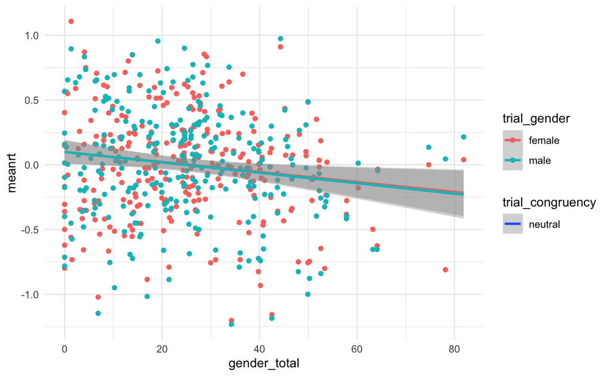

```r
final_spr %>%
  group_by(trial_gender,trial_congruency,workerid,gender_total) %>%
  summarise(meanrt = mean(resid_rt)) %>%
  ggplot(aes(x=gender_total,y=meanrt,color=trial_gender,linetype=trial_congruency)) +
  geom_point() +
  geom_smooth(method="lm")
```

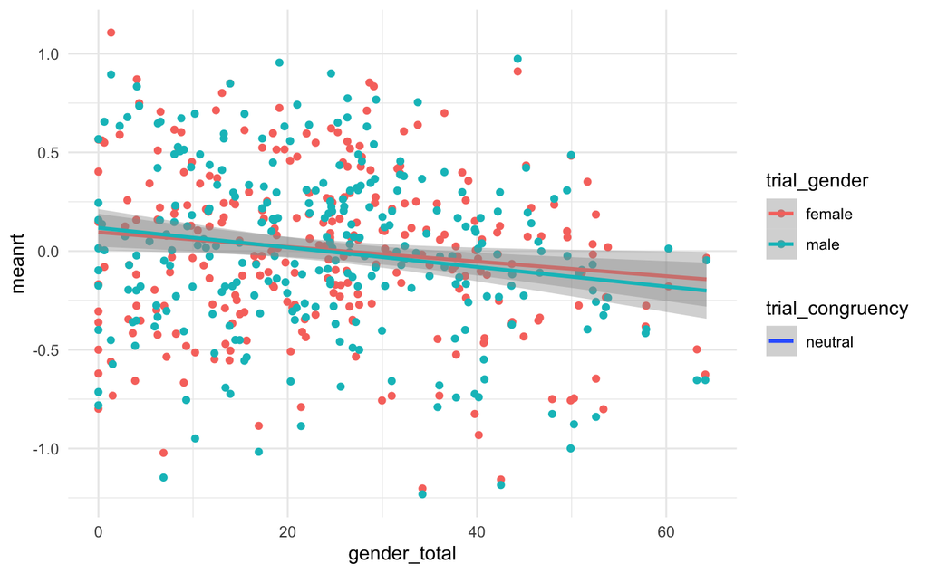

```r
final_spr %>%
  filter(gender_total < 70) %>%
  group_by(trial_gender,trial_congruency,workerid,gender_total) %>%
  summarise(meanrt = mean(resid_rt)) %>%
  ggplot(aes(x=gender_total,y=meanrt,color=trial_gender,linetype=trial_congruency)) +
  geom_point() +
  geom_smooth(method="lm")
```

```r
final_spr <- final_spr %>%
  mutate(log_rt = log(rt)) %>%
  mutate(c_form_length = scale(form_length, scale=FALSE))
```

```r
final_spr <- final_spr %>%
  mutate(c_lex_resid = scale(LexResid),scale=FALSE) %>%
  mutate(c_log_all = scale(log_all),scale=FALSE)
```

```r
model_17 <- lmer(log_rt~c_resid_ideo*c_trial_gender + c_lex_resid + c_log_all*poli_party + c_form_length + (0 + c_form_length | workerid) + (0 + c_lex_resid | workerid) + (1 | workerid) + (1 + c_trial_gender | lexeme), data=final_spr)
```

```r
summary(model_17)
```

```
Linear mixed model fit by REML. t-tests use Satterthwaite's method ['lmerModLmerTest']
Formula: log_rt ~ c_resid_ideo * c_trial_gender + c_lex_resid + c_log_all *      poli_party + c_form_length + (0 + c_form_length | workerid) +
    (0 + c_lex_resid | workerid) + (1 | workerid) + (1 + c_trial_gender |      lexeme)
   Data: final_spr

REML criterion at convergence: 2175.9

Scaled residuals:
    Min      1Q  Median      3Q     Max
-4.2391 -0.5563 -0.0438  0.5106  4.1891

Random effects:
 Groups     Name           Variance Std.Dev. Corr
 workerid   c_form_length  0.000274 0.01655
 workerid.1 c_lex_resid    0.002180 0.04669
 workerid.2 (Intercept)    0.143209 0.37843
 lexeme     (Intercept)    0.002990 0.05468
            c_trial_gender 0.001309 0.03618  0.08
 Residual                  0.091555 0.30258
Number of obs: 2638, groups:  workerid, 274; lexeme, 20

Fixed effects:
                                 Estimate Std. Error         df t value Pr(>|t|)
(Intercept)                     6.281e+00  5.239e-02  2.735e+02 119.896  < 2e-16 ***
c_resid_ideo                   -9.362e-02  2.356e-02  2.677e+02  -3.975 9.07e-05 ***
c_trial_gender                 -7.330e-03  1.463e-02  1.688e+01  -0.501 0.622704
c_lex_resid                    -5.074e-03  1.447e-02  1.750e+01  -0.351 0.729978
c_log_all                      -1.801e-02  2.077e-02  3.659e+01  -0.867 0.391706
poli_partyDemocrat             -6.974e-02  6.284e-02  2.659e+02  -1.110 0.268085
poli_partyRepublican            2.067e-02  6.405e-02  2.666e+02   0.323 0.747216
c_form_length                   2.072e-02  4.574e-03  1.753e+01   4.530 0.000276 ***
c_resid_ideo:c_trial_gender    -9.915e-04  1.218e-02  2.309e+03  -0.081 0.935133
c_log_all:poli_partyDemocrat   -2.616e-03  1.692e-02  1.640e+03  -0.155 0.877182
c_log_all:poli_partyRepublican -1.822e-02  1.741e-02  1.600e+03  -1.046 0.295526
---
Signif. codes:  0 ‘***’ 0.001 ‘**’ 0.01 ‘*’ 0.05 ‘.’ 0.1 ‘ ’ 1

Correlation of Fixed Effects:
            (Intr) c_rsd_ c_trl_ c_lx_r c_lg_l pl_prD pl_prR c_frm_ c__:__ c__:_D
c_resid_ide  0.001
c_tril_gndr  0.011  0.001
c_lex_resid  0.000 -0.004  0.001
c_log_all    0.003  0.002 -0.017 -0.128
pl_prtyDmcr -0.788  0.000  0.000 -0.001 -0.004
pl_prtyRpbl -0.773 -0.003 -0.001 -0.001 -0.003  0.645
c_frm_lngth  0.004  0.001 -0.010 -0.252  0.472 -0.002  0.000
c_rsd_d:c__ -0.001 -0.004 -0.001  0.017  0.022  0.001  0.003 -0.007
c_lg_ll:p_D -0.005 -0.002  0.014  0.004 -0.537  0.007  0.004 -0.014 -0.038
c_lg_ll:p_R -0.005 -0.009  0.008  0.005 -0.519  0.004  0.003 -0.007 -0.030  0.635
optimizer (nloptwrap) convergence code: 0 (OK)
Model failed to converge with max|grad| = 0.00234911 (tol = 0.002, component 1)
```

```r
ultimate_model <- lmer(resid_rt~c_gender_total:subject_information.age + c_log_all*poli_party*subject_information.age + c_gender_total + c_trial_gender + (1 |workerid) + (1|lexeme),data=final_spr)
```

[output not shown]

```r
summary(ultimate_model)
```

[output not shown]

```
Correlation matrix not shown by default, as p = 14 > 12.
Use print(x, correlation=TRUE)  or
    vcov(x)        if you need it
```

```r
vcov(test_model)
```

[output not shown]

[output cut: 66 more lines]

[output not shown]

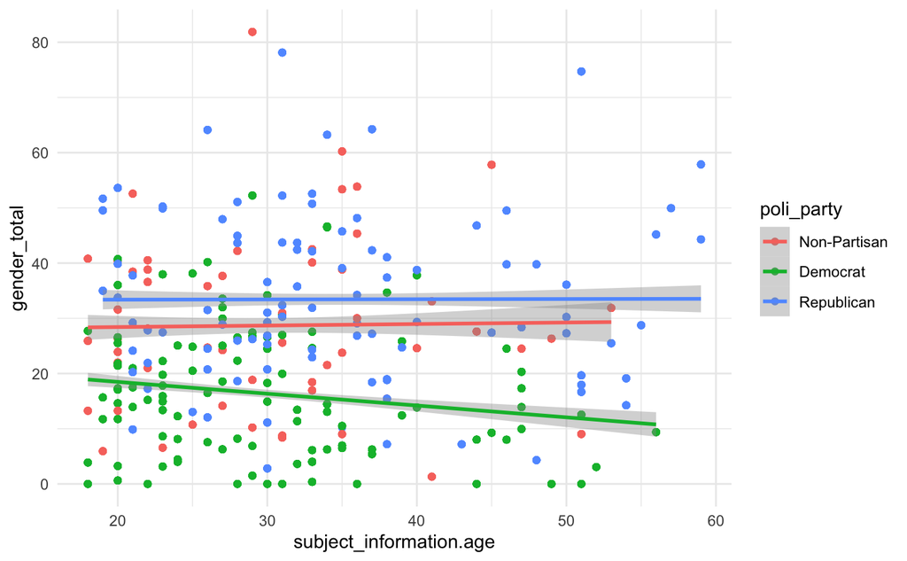

```r
final_spr %>%
  filter(subject_information.age <60) %>%
  group_by(workerid,gender_total,subject_information.age,poli_party) %>%
  unique() %>%
  ggplot(aes(x=subject_information.age,y=gender_total,color=poli_party)) +
  geom_point() +
  geom_smooth(method="lm")
```